# Prepare CPUE data from DATRAS exchange

Author

Max Lindmark

Published

March 18, 2025

# Intro

In this script, I load exchange data from datras and calculate catch of cod and flounder in unit kg/km^2 (with TVL gear) by size group, by correcting for gear dimensions, sweeplength and trawl speed, following Orio et al 2017.

## Load libraries

```r
# Load libraries, install if needed
library(tidyverse)
library(tidylog)
library(RCurl)
library(devtools)
library(patchwork)
library(janitor)
library(icesDatras)
# library(mapdata)
library(raster)
library(mapplots)
library(ggsidekick); theme_set(theme_sleek())

# Set path
home <- here::here()
```

## Read data

```r
# Downloadad 2024.12.02

# Read HH data
# bits_hh <- getDATRAS(record = "HH", survey = "BITS", years = 2010:2023, quarters = c(1, 4))
# write_csv(bits_hh, paste0(home, "/data/datras/bits_hh.csv"))
bits_hh <- read_csv(paste0(home, "/data/datras/bits_hh.csv"))

# Read HL data
# bits_hl <- getDATRAS(record = "HL", survey = "BITS", years = 2010:2023, quarters = c(1, 4))
# write_csv(bits_hl, paste0(home, "/data/datras/bits_hl.csv"))
bits_hl <- read_csv(paste0(home, "/data/datras/bits_hl.csv")) |>
  mutate(StNo = as.character(StNo))
# Read CA data
# bits_ca <- getDATRAS(record = "CA", survey = "BITS", years = 2010:2023, quarters = c(1, 4))
# write_csv(bits_ca, paste0(home, "/data/datras/bits_ca.csv"))
bits_ca <- read_csv(paste0(home, "/data/datras/bits_ca.csv"))
# Read gear standardization data
newsweep <- read.csv(paste0(home, "/data/datras/sweep_9116.csv"), sep = ";", fileEncoding = "windows-1252")
```

## Standardize catch data

#### Create a simple haul ID that works across all exchange data

```r
# Create ID column
bits_ca <- bits_ca |>
  mutate(haul_id = paste(Year, Quarter, Country, Ship, Gear, StNo, HaulNo, sep = ":"))

bits_hl <- bits_hl |>
  mutate(haul_id = paste(Year, Quarter, Country, Ship, Gear, StNo, HaulNo, sep = ":"))

bits_hh <- bits_hh |>
  mutate(haul_id = paste(Year, Quarter, Country, Ship, Gear, StNo, HaulNo, sep = ":"))
```

#### Clean DATRAS EXCHANGE data

```r
# Add ICES rectangle
bits_hh$ices_rect <- mapplots::ices.rect2(lon = bits_hh$ShootLong, lat = bits_hh$ShootLat)

# Add ICES subdivisions
shape <- shapefile(paste0(here::here(), "/data/shapefiles/ICES-StatRec-mapto-ICES-Areas/StatRec_map_Areas_Full_20170124.shp"))

pts <- SpatialPoints(cbind(bits_hh$ShootLong, bits_hh$ShootLat),
  proj4string = CRS(proj4string(shape))
)

bits_hh$sub_div <- over(pts, shape)$Area_27

# Rename subdivisions to the more common names and do some more filtering (by sub div and area)
sort(unique(bits_hh$sub_div))
```

```
 [1] "3.a.20"   "3.a.21"   "3.b.23"   "3.c.22"   "3.d.24"   "3.d.25"
 [7] "3.d.26"   "3.d.27"   "3.d.28.2" "3.d.29"
```

```r
bits_hh <- bits_hh |>
  mutate(
    sub_div = factor(sub_div),
    sub_div = fct_recode(sub_div,
      "20" = "3.a.20",
      "21" = "3.a.21",
      "22" = "3.c.22",
      "23" = "3.b.23",
      "24" = "3.d.24",
      "25" = "3.d.25",
      "26" = "3.d.26",
      "27" = "3.d.27",
      "28" = "3.d.28.1",
      "28" = "3.d.28.2",
      "29" = "3.d.29"
    ),
    sub_div = as.character(sub_div)
  )
```

```r
# Select just valid, additional and no oxygen hauls
bits_hh <- bits_hh |>
  filter(HaulVal %in% c("A", "N", "V"))

# Now add the fishing line information from the sweep file (we need that later to standardize based on gear geometry). We add in the the HH data and then transfer it to the other exchange data files when left_joining. Check which Fishing lines I have in the sweep data:
fishing_line <- newsweep |>
  group_by(Gear) |>
  distinct(Fishing.line)

bits_hh <- left_join(bits_hh, fishing_line, by = "Gear")

# Select the hauls in the HH data when subsetting the HL data
bits_hl <- bits_hl |>
  filter(haul_id %in% bits_hh$haul_id)

bits_hh_merge <- bits_hh |>
  mutate(date = paste(Year, Month, Day, sep = "-")) |>
  dplyr::select(
    sub_div, ices_rect, HaulVal, StdSpecRecCode, BySpecRecCode, Fishing.line, Month,
    DataType, HaulDur, GroundSpeed, haul_id, ShootLat, ShootLong, Day, Month, date
  )

bits_hl <- left_join(bits_hl, bits_hh_merge, by = c("haul_id"))
bits_ca <- left_join(bits_ca, bits_hh_merge, by = c("haul_id"))
```

Add in species names (see get_taxa.R)

```r
tax <- read_csv("https://raw.githubusercontent.com/maxlindmark/BITS/refs/heads/main/output/taxa.csv")

tax
```

```
# A tibble: 15 × 4
   latin_name            common_name SpecCodeType SpecCode
   <chr>                 <chr>       <chr>           <dbl>
 1 Gadus morhua          cod         T              164712
 2 Gadus morhua          cod         W              126436
 3 Platichthys flesus    flounder    T              172894
 4 Platichthys flesus    flounder    W              127141
 5 Platichthys solemdali flounder    W             1264298
 6 Limanda limanda       dab         T              172881
 7 Limanda limanda       dab         W              127139
 8 Merlangius merlangus  whiting     T              164758
 9 Merlangius merlangus  whiting     W              126438
10 Pleuronectes platessa plaice      T              172902
11 Pleuronectes platessa plaice      W              127143
12 Scophthalmus maximus  turbot      T              172748
13 Scophthalmus maximus  turbot      W              127149
14 Psetta maxima         turbot      T              616195
15 Psetta maxima         turbot      W              154473
```

```r
bits_hl <- bits_hl |>
  left_join(tax, by = c("SpecCodeType", "SpecCode")) |>
  rename(Species = latin_name)

bits_ca <- bits_ca |>
  left_join(tax, by = c("SpecCodeType", "SpecCode")) |>
  rename(Species = latin_name)

hlcod <- bits_hl |> filter(common_name == "cod")
hlfle <- bits_hl |> filter(common_name == "flounder")
hldab <- bits_hl |> filter(common_name == "dab")
hlwhi <- bits_hl |> filter(common_name == "whiting")
hlpla <- bits_hl |> filter(common_name == "plaice")
hltur <- bits_hl |> filter(common_name == "turbot")
```

#### Prepare to add 0 catches

```r
# Find common columns in the HH and HL data (here already subset by species)
comcol <- intersect(names(hlcod), names(bits_hh))


##### Cod: Add 0s and then remove lines with SpecVal = 0 (first NA because we don't have a match in the HH, then make them 0 later)
hlcod0 <- full_join(hlcod, bits_hh[, comcol], by = comcol)

hlcod0$SpecVal[is.na(hlcod0$SpecVal)] <- "zeroCatch"

hlcod0$SpecVal <- factor(hlcod0$SpecVal)

hlcod0 <- hlcod0 |> filter(!SpecVal == "0")

# Add species again after merge
hlcod0$Species <- "Gadus morhua"


##### Flounder: add 0s, remove them if StdSpecRecCode !=1 and then remove lines with SpecVal = 0
hlfle0 <- full_join(hlfle, bits_hh[, comcol], by = comcol)

hlfle0 <- hlfle0[!(is.na(hlfle0$Species) & hlfle0$StdSpecRecCode != 1), ]

hlfle0$SpecVal[is.na(hlfle0$SpecVal)] <- "zeroCatch"
hlfle0$SpecVal <- factor(hlfle0$SpecVal)

hlfle0 <- hlfle0 |>
  filter(SpecVal != "0")

hlfle0$Species <- "Platichthys flesus"


##### Plaice: add 0s, remove them if StdSpecRecCode !=1 and then remove lines with SpecVal = 0
hlpla0 <- full_join(hlpla, bits_hh[, comcol], by = comcol)

hlpla0 <- hlpla0[!(is.na(hlpla0$Species) & hlpla0$StdSpecRecCode != 1), ]

hlpla0$SpecVal[is.na(hlpla0$SpecVal)] <- "zeroCatch"
hlpla0$SpecVal <- factor(hlpla0$SpecVal)

hlpla0 <- hlpla0 |>
  filter(SpecVal != "0")

hlpla0$Species <- "Pleuronectes platessa"


##### Dab: add 0s, remove them if BycSpecRecCode !=1 and then remove lines with SpecVal = 0
hldab0 <- full_join(hldab, bits_hh[, comcol], by = comcol)

hldab0 <- hldab0[!(is.na(hldab0$Species) & hldab0$BySpecRecCode != 1), ]

hldab0$SpecVal[is.na(hldab0$SpecVal)] <- "zeroCatch"
hldab0$SpecVal <- factor(hldab0$SpecVal)

hldab0 <- hldab0 |>
  filter(SpecVal != "0")

hldab0$Species <- "Limanda limanda"


##### Turbot: add 0s, remove them if BycSpecRecCode !=1 and then remove lines with SpecVal = 0
hltur0 <- full_join(hltur, bits_hh[, comcol], by = comcol)

hltur0 <- hltur0[!(is.na(hltur0$Species) & hltur0$BySpecRecCode != 1), ]

hltur0$SpecVal[is.na(hltur0$SpecVal)] <- "zeroCatch"
hltur0$SpecVal <- factor(hltur0$SpecVal)

hltur0 <- hltur0 |>
  filter(SpecVal != "0")

hltur0$Species <- "Psetta maxima"


##### Whiting: add 0s, remove them if BycSpecRecCode !=1 and then remove lines with SpecVal = 0
hlwhi0 <- full_join(hlwhi, bits_hh[, comcol], by = comcol)

hlwhi0 <- hlwhi0[!(is.na(hlwhi0$Species) & hlwhi0$BySpecRecCode != 1), ]

hlwhi0$SpecVal[is.na(hlwhi0$SpecVal)] <- "zeroCatch"
hlwhi0$SpecVal <- factor(hlwhi0$SpecVal)

hlwhi0 <- hlwhi0 |>
  filter(SpecVal != "0")

hlwhi0$Species <- "Merlangius merlangus"
```

#### Create (unstandardized) CPUE for `SpecVal=1`. If `DataType=C` then `CPUEun=HLNoAtLngt`, if `DataType=R` then `CPUEun=HLNoAtLngt/(HaulDur/60)`, if `DataType=S` then `CPUEun=(HLNoAtLngt*SubFactor)/(HaulDur/60)`. If `SpecVal="zeroCatch"` then `CPUEun=0`, if `SpecVal=4` we need to decide (no length measurements, only total catch). Note that here we also add zero CPUE if `SpecVal=="zeroCatch"`.

Then I will sum for the same haul the CPUE of the same length classes if they were sampled with different subfactors or with different sexes.

```r
##### Cod
hlcod0 <- hlcod0 |>
  mutate(CPUEun = ifelse(SpecVal == "1" & DataType == "C", HLNoAtLngt,
    ifelse(SpecVal == "1" & DataType == "R", HLNoAtLngt / (HaulDur / 60),
      ifelse(SpecVal == "1" & DataType == "S", (HLNoAtLngt * SubFactor) / (HaulDur / 60),
        ifelse(SpecVal == "zeroCatch", 0, NA)
      )
    )
  ))

# Some rows have multiple rows per combination of length class and haul id (i suppose often because it's split by sex), so we need to sum it up
hlcod0 |>
  group_by(LngtClass, haul_id) |>
  mutate(n = n()) |>
  ungroup() |>
  distinct(n)
```

```
# A tibble: 2 × 1
      n
  <int>
1     1
2     2
```

```r
hlcod0 |>
  group_by(LngtClass, haul_id) |>
  mutate(n = n()) |>
  ungroup() |>
  filter(n == 2) |>
  as.data.frame() |>
  head(5)
```

```
  RecordType Survey Quarter Country Ship Gear SweepLngt GearEx DoorType StNo
1         HL   BITS       4      DK 26HI  TVS        NA      S       NA  657
2         HL   BITS       4      DK 26HI  TVS        NA      S       NA  657
3         HL   BITS       4      DK 26HI  TVS        NA      S       NA  657
4         HL   BITS       4      DK 26HI  TVS        NA      S       NA  657
5         HL   BITS       4      DK 26HI  TVS        NA      S       NA  657
  HaulNo Year SpecCodeType SpecCode SpecVal  Sex TotalNo CatIdentifier NoMeas
1     40 2013            W   126436       1 <NA>     256             1     64
2     40 2013            W   126436       1 <NA>     256             1     64
3     40 2013            W   126436       1 <NA>     256             1     64
4     40 2013            W   126436       1 <NA>     256             1     64
5     40 2013            W   126436       1 <NA>      27             2     27
  SubFactor SubWgt CatCatchWgt LngtCode LngtClass HLNoAtLngt DevStage
1         4   1600        6400        .       150          7       NA
2         4   1600        6400        .       160          5       NA
```

[output cut: 27 more lines]

```r
hlcodL <- hlcod0 |>
  group_by(LngtClass, haul_id) |>
  mutate(CPUEun = sum(CPUEun)) |>
  ungroup() |>
  mutate(id3 = paste(haul_id, LngtClass)) |>
  distinct(id3, .keep_all = TRUE) |>
  dplyr::select(-id3)


##### Flounder
hlfle0 <- hlfle0 |>
  mutate(CPUEun = ifelse(SpecVal == "1" & DataType == "C", HLNoAtLngt,
                         ifelse(SpecVal == "1" & DataType == "R", HLNoAtLngt / (HaulDur / 60),
                                ifelse(SpecVal == "1" & DataType == "S", (HLNoAtLngt * SubFactor) / (HaulDur / 60),
                                       ifelse(SpecVal == "zeroCatch", 0, NA)
                                       )
                                )
                         )
         )

hlfle0 |>
  group_by(LngtClass, haul_id) |>
  mutate(n = n()) |>
  ungroup() |>
  distinct(n)
```

```
# A tibble: 2 × 1
      n
  <int>
1     1
2     2
```

```r
hlfle0 |>
  group_by(LngtClass, haul_id) |>
  mutate(n = n()) |>
  ungroup() |>
  filter(n == 2) |>
  as.data.frame() |>
  arrange(haul_id, LngtClass) |>
  head(5)
```

```
  RecordType Survey Quarter Country Ship Gear SweepLngt GearEx DoorType  StNo
1         HL   BITS       1      LT LTDA  TVS        NA   <NA>       NA 26028
2         HL   BITS       1      LT LTDA  TVS        NA   <NA>       NA 26028
3         HL   BITS       1      LT LTDA  TVS        NA   <NA>       NA 26052
4         HL   BITS       1      LT LTDA  TVS        NA   <NA>       NA 26052
5         HL   BITS       1      LT LTDA  TVS        NA   <NA>       NA 26134
  HaulNo Year SpecCodeType SpecCode SpecVal Sex TotalNo CatIdentifier NoMeas
1      8 2010            T   172894       1   F      12             1      6
2      8 2010            T   172894       1   M      12             1      6
3      7 2010            T   172894       1   M      12             1      6
4      7 2010            T   172894       1   F      18             1      9
5      1 2010            T   172894       1   M      66             1     33
  SubFactor SubWgt CatCatchWgt LngtCode LngtClass HLNoAtLngt DevStage
1         2   2500        5000        1        22          1       NA
2         2   2500        5000        1        22          1       NA
```

[output cut: 27 more lines]

```r
hlfleL <- hlfle0 |>
  group_by(LngtClass, haul_id) |>
  mutate(CPUEun = sum(CPUEun)) |>
  ungroup() |>
  mutate(id3 = paste(haul_id, LngtClass)) |>
  distinct(id3, .keep_all = TRUE) |>
  dplyr::select(-id3)


#### Plaice
hlpla0 <- hlpla0 |>
  mutate(CPUEun = ifelse(SpecVal == "1" & DataType == "C", HLNoAtLngt,
                         ifelse(SpecVal == "1" & DataType == "R", HLNoAtLngt / (HaulDur / 60),
                                ifelse(SpecVal == "1" & DataType == "S", (HLNoAtLngt * SubFactor) / (HaulDur / 60),
                                       ifelse(SpecVal == "zeroCatch", 0, NA)
                                       )
                                )
                         )
         )

hlplaL <- hlpla0 |>
  group_by(LngtClass, haul_id) |>
  mutate(CPUEun = sum(CPUEun)) |>
  ungroup() |>
  mutate(id3 = paste(haul_id, LngtClass)) |>
  distinct(id3, .keep_all = TRUE) |>
  dplyr::select(-id3)


#### Dab
hldab0 <- hldab0 |>
  mutate(CPUEun = ifelse(SpecVal == "1" & DataType == "C", HLNoAtLngt,
                         ifelse(SpecVal == "1" & DataType == "R", HLNoAtLngt / (HaulDur / 60),
                                ifelse(SpecVal == "1" & DataType == "S", (HLNoAtLngt * SubFactor) / (HaulDur / 60),
                                       ifelse(SpecVal == "zeroCatch", 0, NA)
                                       )
                                )
                         )
         )

hldab0 |>
  group_by(LngtClass, haul_id) |>
  mutate(n = n()) |>
  ungroup() |>
  distinct(n)
```

```
# A tibble: 3 × 1
      n
  <int>
1     1
2     2
3     3
```

```r
hldab0 |>
  group_by(LngtClass, haul_id) |>
  mutate(n = n()) |>
  ungroup() |>
  filter(n == 2) |>
  as.data.frame() |>
  arrange(haul_id, LngtClass) |>
  head(6)
```

```
  RecordType Survey Quarter Country Ship Gear SweepLngt GearEx DoorType StNo
1         HL   BITS       1      DK 26HF  TVS        NA      S       NA    4
2         HL   BITS       1      DK 26HF  TVS        NA      S       NA    4
3         HL   BITS       1      DK 26HF  TVS        NA      S       NA    4
4         HL   BITS       1      DK 26HF  TVS        NA      S       NA    4
5         HL   BITS       1      DK 26HF  TVS        NA      S       NA    4
6         HL   BITS       1      DK 26HF  TVS        NA      S       NA    4
  HaulNo Year SpecCodeType SpecCode SpecVal  Sex TotalNo CatIdentifier NoMeas
1      4 2017            W   127139       1 <NA> 1775.31             1     77
2      4 2017            W   127139       1 <NA> 1775.31             1     77
3      4 2017            W   127139       1 <NA> 1775.31             1     77
4      4 2017            W   127139       1 <NA> 1775.31             1     77
5      4 2017            W   127139       1 <NA> 1775.31             1     77
6      4 2017            W   127139       1 <NA> 1775.31             1     77
  SubFactor SubWgt CatCatchWgt LngtCode LngtClass HLNoAtLngt DevStage
```

[output cut: 34 more lines]

```r
hldabL <- hldab0 |>
  group_by(LngtClass, haul_id) |>
  mutate(CPUEun = sum(CPUEun)) |>
  ungroup() |>
  mutate(id3 = paste(haul_id, LngtClass)) |>
  distinct(id3, .keep_all = TRUE) |>
  dplyr::select(-id3)


#### Turbot
hltur0 <- hltur0 |>
  mutate(CPUEun = ifelse(SpecVal == "1" & DataType == "C", HLNoAtLngt,
                         ifelse(SpecVal == "1" & DataType == "R", HLNoAtLngt / (HaulDur / 60),
                                ifelse(SpecVal == "1" & DataType == "S", (HLNoAtLngt * SubFactor) / (HaulDur / 60),
                                       ifelse(SpecVal == "zeroCatch", 0, NA)
                                       )
                                )
                         )
         )

hltur0 |>
  group_by(LngtClass, haul_id) |>
  mutate(n = n()) |>
  ungroup() |>
  distinct(n)
```

```
# A tibble: 2 × 1
      n
  <int>
1     1
2     2
```

```r
hltur0 |>
  group_by(LngtClass, haul_id) |>
  mutate(n = n()) |>
  ungroup() |>
  filter(n == 2) |>
  as.data.frame() |>
  arrange(haul_id, LngtClass) |>
  head(4)
```

```
  RecordType Survey Quarter Country Ship Gear SweepLngt GearEx DoorType StNo
1         HL   BITS       1      LV 67BC  TVL        75      R     TRUE    1
2         HH   BITS       1      LV 67BC  TVL        75      R     TRUE    1
3         HL   BITS       1      LV 67BC  TVL        75      R     TRUE    1
4         HH   BITS       1      LV 67BC  TVL        75      R     TRUE    1
  HaulNo Year SpecCodeType SpecCode   SpecVal  Sex TotalNo CatIdentifier NoMeas
1     10 2010            W   127149         4 <NA>       2             1     NA
2     10 2010         <NA>       NA zeroCatch <NA>      NA            NA     NA
3     14 2010            W   127149         4 <NA>       6             1     NA
4     14 2010         <NA>       NA zeroCatch <NA>      NA            NA     NA
  SubFactor SubWgt CatCatchWgt LngtCode LngtClass HLNoAtLngt DevStage
1         1     NA         700     <NA>        NA         -9       NA
2        NA     NA          NA     <NA>        NA         NA       NA
3         1     NA        1065     <NA>        NA         -9       NA
4        NA     NA          NA     <NA>        NA         NA       NA
```

[output cut: 20 more lines]

```r
hlturL <- hltur0 |>
  group_by(LngtClass, haul_id) |>
  mutate(CPUEun = sum(CPUEun)) |>
  ungroup() |>
  mutate(id3 = paste(haul_id, LngtClass)) |>
  distinct(id3, .keep_all = TRUE) |>
  dplyr::select(-id3)


# Whiting
hlwhi0 <- hlwhi0 |>
  mutate(CPUEun = ifelse(SpecVal == "1" & DataType == "C", HLNoAtLngt,
                         ifelse(SpecVal == "1" & DataType == "R", HLNoAtLngt / (HaulDur / 60),
                                ifelse(SpecVal == "1" & DataType == "S", (HLNoAtLngt * SubFactor) / (HaulDur / 60),
                                       ifelse(SpecVal == "zeroCatch", 0, NA)
                                       )
                                )
                         )
         )

hlwhi0 |>
  group_by(LngtClass, haul_id) |>
  mutate(n = n()) |>
  ungroup() |>
  distinct(n)
```

```
# A tibble: 2 × 1
      n
  <int>
1     1
2     2
```

```r
hlwhi0 |>
  group_by(LngtClass, haul_id) |>
  mutate(n = n()) |>
  ungroup() |>
  filter(n == 2) |>
  as.data.frame() |>
  arrange(haul_id, LngtClass) |>
  head(4)
```

```
  RecordType Survey Quarter Country Ship Gear SweepLngt GearEx DoorType StNo
1         HL   BITS       1      RU RUJB  TVL        NA   <NA>       NA   56
2         HH   BITS       1      RU RUJB  TVL        NA   <NA>       NA   56
3         HL   BITS       1      RU RUJB  TVL        NA   <NA>       NA   56
4         HH   BITS       1      RU RUJB  TVL        NA   <NA>       NA   56
  HaulNo Year SpecCodeType SpecCode   SpecVal  Sex TotalNo CatIdentifier NoMeas
1     24 2011            T   164758         4 <NA>       2             1     NA
2     24 2011         <NA>       NA zeroCatch <NA>      NA            NA     NA
3     32 2011            T   164758         4 <NA>       4             1     NA
4     32 2011         <NA>       NA zeroCatch <NA>      NA            NA     NA
  SubFactor SubWgt CatCatchWgt LngtCode LngtClass HLNoAtLngt DevStage
1         1     NA         510     <NA>        NA         -9       NA
2        NA     NA          NA     <NA>        NA         NA       NA
3         1     NA         480     <NA>        NA         -9       NA
4        NA     NA          NA     <NA>        NA         NA       NA
```

[output cut: 20 more lines]

```r
hlwhiL <- hlwhi0 |>
  group_by(LngtClass, haul_id) |>
  mutate(CPUEun = sum(CPUEun)) |>
  ungroup() |>
  mutate(id3 = paste(haul_id, LngtClass)) |>
  distinct(id3, .keep_all = TRUE) |>
  dplyr::select(-id3)
```

#### Get and add annual weight-length relationships from the CA data so that I can calculate CPUE in biomass rather than numbers further down

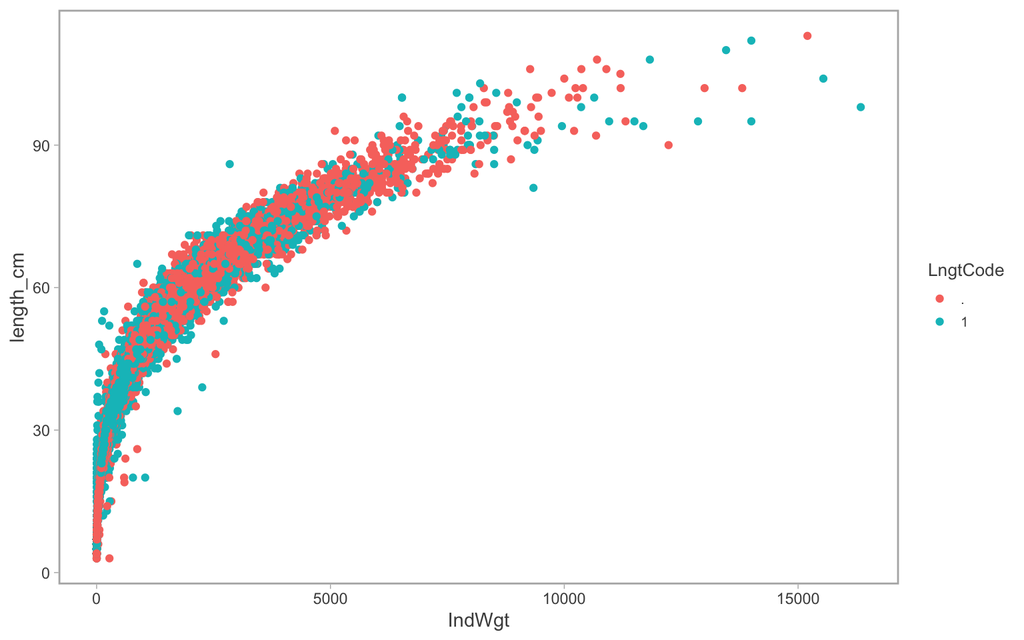

```r
#### Cod
bits_ca_cod <- bits_ca |>
  filter(Species == "Gadus morhua") |>
  mutate(StNo = as.numeric(StNo)) |>
  mutate(ID = paste(Year, Quarter, Country, Ship, Gear, StNo, HaulNo, sep = "."))

# Now I need to copy rows with NoAtLngt > 1 so that 1 row = 1 ind
bits_ca_cod <- bits_ca_cod %>% map_df(., rep, .$CANoAtLngt)

# Standardize length and drop NA weights (need that for condition)
bits_ca_cod <- bits_ca_cod |>
  drop_na(IndWgt) |>
  drop_na(LngtClass) |>
  filter(IndWgt > 0 & LngtClass > 0) |> # Filter positive length and weight
  mutate(weight_kg = IndWgt / 1000) |>
  mutate(length_cm = ifelse(LngtCode == ".",
    LngtClass / 10,
    LngtClass
  )) |> # Standardize length ((https://vocab.ices.dk/?ref=18))
  filter(!(IndWgt > 12000 & LngtClass < 60))

ggplot(bits_ca_cod, aes(IndWgt, length_cm, color = LngtCode)) +
  geom_point()
```

```r
# Now extract the coefficients for each year (not bothering with outliers at the moment)
lwCOD <- bits_ca_cod %>%
  split(.$Year) |>
  purrr::map(~ lm(log(IndWgt) ~ log(length_cm), data = .x)) |>
  purrr::map_df(broom::tidy, .id = "Year") |>
  dplyr::select(Year, term, estimate) |>
  pivot_wider(names_from = term, values_from = estimate) |>
  mutate(aL = exp(`(Intercept)`)) |>
  dplyr::select(-`(Intercept)`) |>
  rename(b = `log(length_cm)`) |>
  filter(b > 2 & b < 4) |>
  filter(aL > 0.00001 & aL < 0.1) |>
  mutate(Year = as.numeric(Year))

# Join the annual L-W relationships to the respective catch data to calculate CPUE in biomass not abundance
hlcodL <- left_join(hlcodL, lwCOD, by = "Year")

unique(bits_ca$Species)
```

```
[1] "Gadus morhua"          "Pleuronectes platessa" "Limanda limanda"
[4] "Platichthys flesus"    "Scophthalmus maximus"  NA
[7] "Psetta maxima"         "Merlangius merlangus"
```

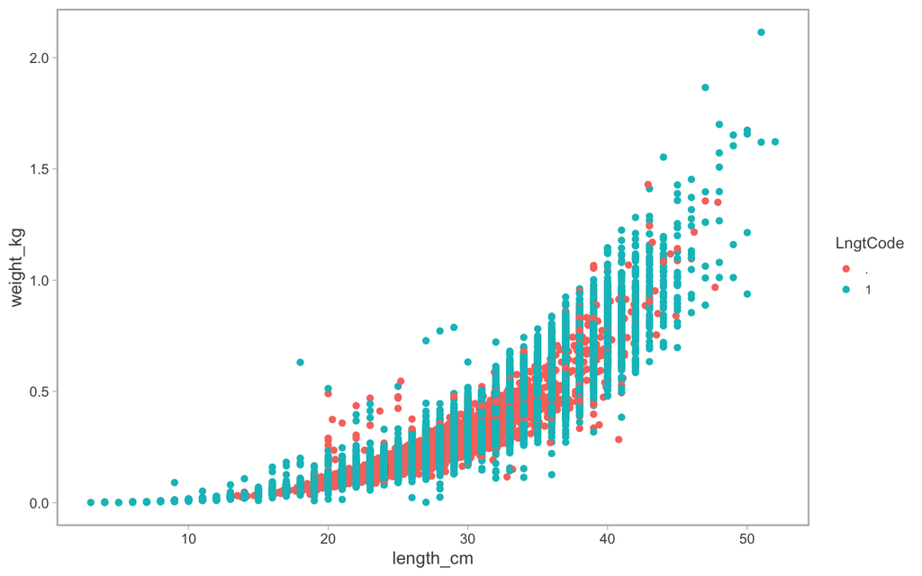

```r
#### Flounder
bits_ca_fle <- bits_ca |>
  filter(Species == "Platichthys flesus") |>
  mutate(StNo = as.numeric(StNo)) |>
  mutate(ID = paste(Year, Quarter, Country, Ship, Gear, StNo, HaulNo, sep = "."))

# Now I need to copy rows with NoAtLngt > 1 so that 1 row = 1 ind
bits_ca_fle <- bits_ca_fle %>% map_df(., rep, .$CANoAtLngt)

# Standardize length and drop NA weights (need that for condition)
bits_ca_fle <- bits_ca_fle |>
  drop_na(IndWgt) |>
  drop_na(LngtClass) |>
  filter(IndWgt > 0 & LngtClass > 0) |> # Filter positive length and weight
  mutate(weight_kg = IndWgt / 1000) |>
  mutate(length_cm = ifelse(LngtCode == ".",
    LngtClass / 10,
    LngtClass
  )) |>
  mutate(length_cm = ifelse(length_cm > 150, length_cm/10, length_cm))

ggplot(bits_ca_fle, aes(length_cm, weight_kg, color = LngtCode)) +
  geom_point()
```

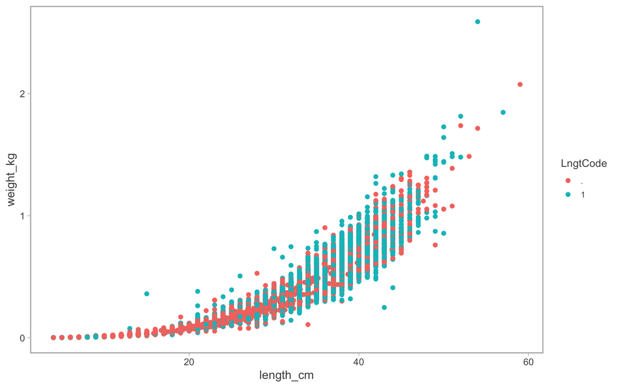

```r
# Now extract the coefficients for each year (not bothering with outliers at the moment)
lwFLE <- bits_ca_fle %>%
  split(.$Year) |>
  purrr::map(~ lm(log(IndWgt) ~ log(length_cm), data = .x)) |>
  purrr::map_df(broom::tidy, .id = "Year") |>
  dplyr::select(Year, term, estimate) |>
  pivot_wider(names_from = term, values_from = estimate) |>
  mutate(aL = exp(`(Intercept)`)) |>
  dplyr::select(-`(Intercept)`) |>
  rename(b = `log(length_cm)`) |>
  filter(b > 2 & b < 4) |>
  filter(aL > 0.00001 & aL < 0.1) |>
  mutate(Year = as.numeric(Year))

# Join the annual L-W relationships to the respective catch data to calculate CPUE in biomass not abundance
hlfleL <- left_join(hlfleL, lwFLE, by = "Year")


#### Plaice
bits_ca_pla <- bits_ca |>
  filter(Species == "Pleuronectes platessa") |>
  mutate(StNo = as.numeric(StNo)) |>
  mutate(ID = paste(Year, Quarter, Country, Ship, Gear, StNo, HaulNo, sep = "."))

# Now I need to copy rows with NoAtLngt > 1 so that 1 row = 1 ind
bits_ca_pla <- bits_ca_pla %>% map_df(., rep, .$CANoAtLngt)

# Standardize length and drop NA weights (need that for condition)
bits_ca_pla <- bits_ca_pla |>
  drop_na(IndWgt) |>
  drop_na(LngtClass) |>
  filter(IndWgt > 0 & LngtClass > 0) |> # Filter positive length and weight
  mutate(weight_kg = IndWgt / 1000) |>
  mutate(length_cm = ifelse(LngtCode == ".",
    LngtClass / 10,
    LngtClass
  )) |>
  filter(length_cm < 75 & length_cm > 3)

ggplot(bits_ca_pla, aes(length_cm, weight_kg, color = LngtCode)) +
  geom_point()
```

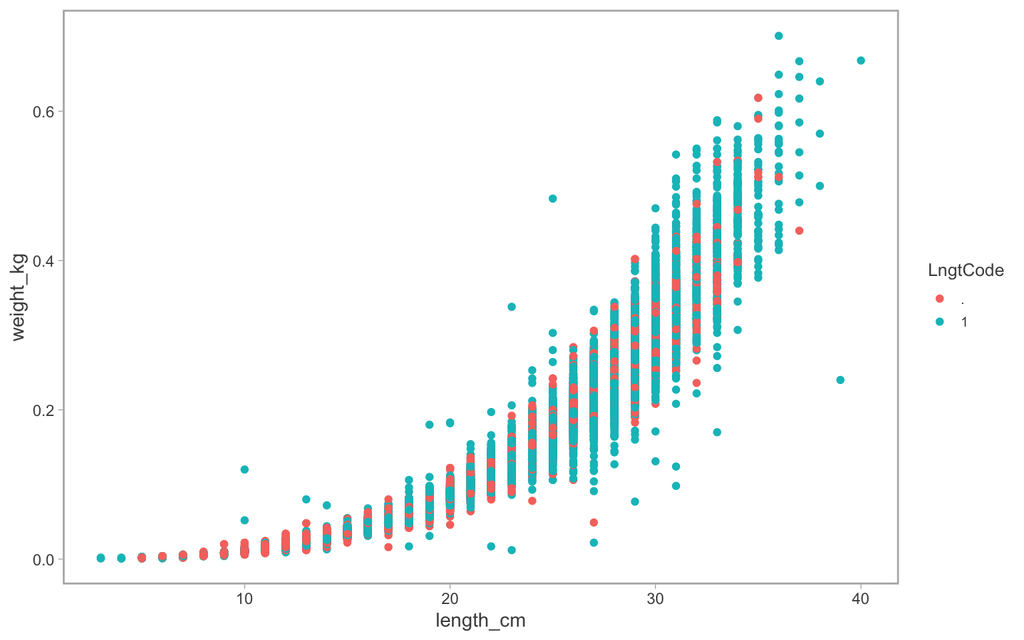

```r
# Now extract the coefficients for each year (not bothering with outliers at the moment)
lwPLA <- bits_ca_pla %>%
  split(.$Year) |>
  purrr::map(~ lm(log(IndWgt) ~ log(length_cm), data = .x)) |>
  purrr::map_df(broom::tidy, .id = "Year") |>
  dplyr::select(Year, term, estimate) |>
  pivot_wider(names_from = term, values_from = estimate) |>
  mutate(aL = exp(`(Intercept)`)) |>
  dplyr::select(-`(Intercept)`) |>
  rename(b = `log(length_cm)`) |>
  filter(b > 2 & b < 4) |>
  filter(aL > 0.00001 & aL < 0.1) |>
  mutate(Year = as.numeric(Year))

# Join the annual L-W relationships to the respective catch data to calculate CPUE in biomass not abundance
hlplaL <- left_join(hlplaL, lwPLA, by = "Year")



#### Dab
bits_ca_dab <- bits_ca |>
  filter(Species == "Limanda limanda") |>
  mutate(StNo = as.numeric(StNo)) |>
  mutate(ID = paste(Year, Quarter, Country, Ship, Gear, StNo, HaulNo, sep = "."))

# Now I need to copy rows with NoAtLngt > 1 so that 1 row = 1 ind
bits_ca_dab <- bits_ca_dab %>% map_df(., rep, .$CANoAtLngt)

# Standardize length and drop NA weights (need that for condition)
bits_ca_dab <- bits_ca_dab |>
  drop_na(IndWgt) |>
  drop_na(LngtClass) |>
  filter(IndWgt > 0 & LngtClass > 0) |> # Filter positive length and weight
  mutate(weight_kg = IndWgt / 1000) |>
  mutate(length_cm = ifelse(LngtCode == ".",
    LngtClass / 10,
    LngtClass
  )) |>
  filter(weight_kg < 0.8)

ggplot(bits_ca_dab, aes(length_cm, weight_kg, color = LngtCode)) +
  geom_point()
```

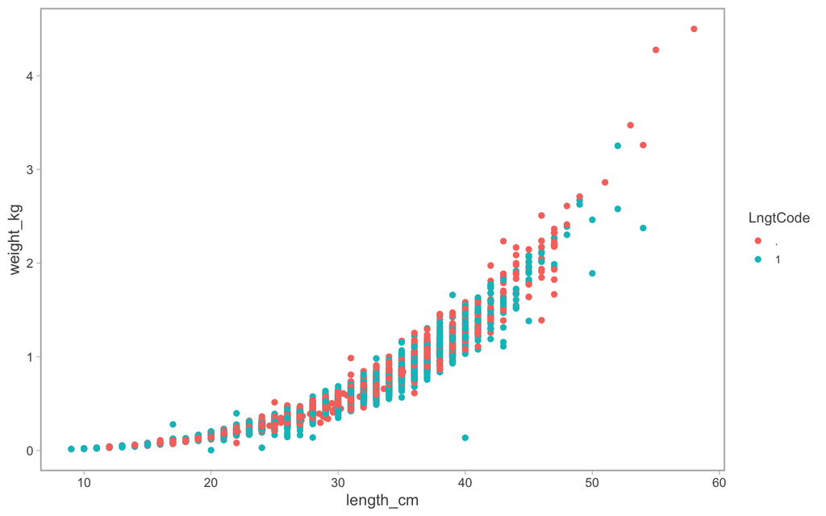

```r
# Now extract the coefficients for each year (not bothering with outliers at the moment)
lwDAB <- bits_ca_dab %>%
  split(.$Year) |>
  purrr::map(~ lm(log(IndWgt) ~ log(length_cm), data = .x)) |>
  purrr::map_df(broom::tidy, .id = "Year") |>
  dplyr::select(Year, term, estimate) |>
  pivot_wider(names_from = term, values_from = estimate) |>
  mutate(aL = exp(`(Intercept)`)) |>
  dplyr::select(-`(Intercept)`) |>
  rename(b = `log(length_cm)`) |>
  filter(b > 2 & b < 4) |>
  filter(aL > 0.00001 & aL < 0.1) |>
  mutate(Year = as.numeric(Year))

# Join the annual L-W relationships to the respective catch data to calculate CPUE in biomass not abundance
hldabL <- left_join(hldabL, lwDAB, by = "Year")


#### Turbot
bits_ca_tur <- bits_ca |>
  filter(common_name == "turbot") |>
  mutate(StNo = as.numeric(StNo)) |>
  mutate(ID = paste(Year, Quarter, Country, Ship, Gear, StNo, HaulNo, sep = "."))

# Now I need to copy rows with NoAtLngt > 1 so that 1 row = 1 ind
bits_ca_tur <- bits_ca_tur %>% map_df(., rep, .$CANoAtLngt)

# Standardize length and drop NA weights (need that for condition)
bits_ca_tur <- bits_ca_tur |>
  drop_na(IndWgt) |>
  drop_na(LngtClass) |>
  filter(IndWgt > 0 & LngtClass > 0) |> # Filter positive length and weight
  mutate(weight_kg = IndWgt / 1000) |>
  mutate(length_cm = ifelse(LngtCode == ".",
    LngtClass / 10,
    LngtClass
  )) |>
  filter(length_cm < 100)

ggplot(bits_ca_tur, aes(length_cm, weight_kg, color = LngtCode)) +
  geom_point()
```

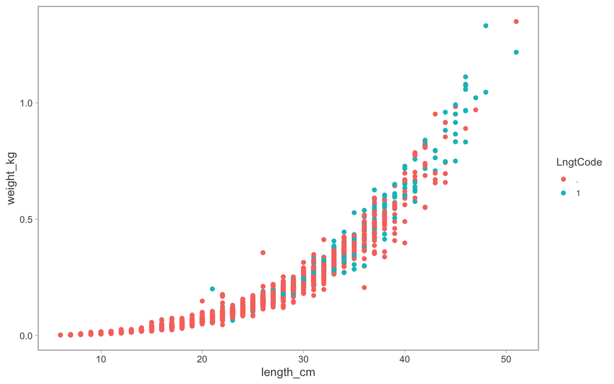

```r
# Now extract the coefficients for each year (not bothering with outliers at the moment)
lwTUR <- bits_ca_tur %>%
  split(.$Year) |>
  purrr::map(~ lm(log(IndWgt) ~ log(length_cm), data = .x)) |>
  purrr::map_df(broom::tidy, .id = "Year") |>
  dplyr::select(Year, term, estimate) |>
  pivot_wider(names_from = term, values_from = estimate) |>
  mutate(aL = exp(`(Intercept)`)) |>
  dplyr::select(-`(Intercept)`) |>
  rename(b = `log(length_cm)`) |>
  filter(b > 2 & b < 4) |>
  filter(aL > 0.00001 & aL < 0.1) |>
  mutate(Year = as.numeric(Year))

# Join the annual L-W relationships to the respective catch data to calculate CPUE in biomass not abundance
hlturL <- left_join(hlturL, lwTUR, by = "Year")


#### Whiting
bits_ca_whi <- bits_ca |>
  filter(common_name == "whiting") |>
  mutate(StNo = as.numeric(StNo)) |>
  mutate(ID = paste(Year, Quarter, Country, Ship, Gear, StNo, HaulNo, sep = "."))

# Now I need to copy rows with NoAtLngt > 1 so that 1 row = 1 ind
bits_ca_whi <- bits_ca_whi %>% map_df(., rep, .$CANoAtLngt)

# Standardize length and drop NA weights (need that for condition)
bits_ca_whi <- bits_ca_whi |>
  drop_na(IndWgt) |>
  drop_na(LngtClass) |>
  filter(IndWgt > 0 & LngtClass > 0) |> # Filter positive length and weight
  mutate(weight_kg = IndWgt / 1000) |>
  mutate(length_cm = ifelse(LngtCode == ".",
    LngtClass / 10,
    LngtClass
  ))

ggplot(bits_ca_whi, aes(length_cm, weight_kg, color = LngtCode)) +
  geom_point()
```

```r
# Now extract the coefficients for each year (not bothering with outliers at the moment)
lwWHI <- bits_ca_whi %>%
  split(.$Year) |>
  purrr::map(~ lm(log(IndWgt) ~ log(length_cm), data = .x)) |>
  purrr::map_df(broom::tidy, .id = "Year") |>
  dplyr::select(Year, term, estimate) |>
  pivot_wider(names_from = term, values_from = estimate) |>
  mutate(aL = exp(`(Intercept)`)) |>
  dplyr::select(-`(Intercept)`) |>
  rename(b = `log(length_cm)`) |>
  filter(b > 2 & b < 4) |>
  filter(aL > 0.00001 & aL < 0.1) |>
  mutate(Year = as.numeric(Year))

# Join the annual L-W relationships to the respective catch data to calculate CPUE in biomass not abundance
hlwhiL <- left_join(hlwhiL, lwWHI, by = "Year")

# Add in the mean parameters for the missing years...
hlwhiL <- hlwhiL |>
  mutate(aL = ifelse(is.na(aL), mean(lwWHI$aL), aL),
         b = ifelse(is.na(b), mean(lwWHI$b), b))
```

#### Convert from CPUE in numbers to $\text{kg/km}^2$

```r
#### Cod
# Standardize length to cm
hlcodL <- hlcodL |>
  mutate(length_cm = ifelse(LngtCode == ".",
    LngtClass / 10,
    LngtClass
  )) # Standardize length ((https://vocab.ices.dk/?ref=18))

#hist(hlcodL$length_cm)

# Now check if all rows where length is NA are the ones with zero catch!
hlcodL |>
  filter(CPUEun == 0) |>
  distinct(length_cm)
```

```
# A tibble: 1 × 1
  length_cm
      <dbl>
1        NA
```

```r
hlcodL |>
  filter(is.na(length_cm)) |>
  distinct(CPUEun)
```

```
# A tibble: 1 × 1
  CPUEun
   <dbl>
1      0
```

```r
# In other words, a zero catch is when the catch is zero and length_cm is NA
# In order to not get any NA CPUEs in unit biomass because length is NA (I want them instead to be 0, as the numbers-CPUE is), I will replace length_cm == NA with length_cm == 0 before calculating biomass CPUE
hlcodL <- hlcodL |> mutate(length_cm2 = replace_na(length_cm, 0))

# Calculate weight of catch
hlcodL <- hlcodL |>
  mutate(weight_kg = (aL * length_cm2^b) / 1000) |>
  mutate(CPUEun_kg = weight_kg * CPUEun)


#### Flounder
# Standardize length to cm
hlfleL <- hlfleL |>
  mutate(length_cm = ifelse(LngtCode == ".",
    LngtClass / 10,
    LngtClass
  )) |>  # Standardize length ((https://vocab.ices.dk/?ref=18))
  mutate(length_cm = ifelse(length_cm > 100, length_cm/10, length_cm))

# hist(hlfleL$length_cm)

# Now check if all rows where length is NA are the ones with zero catch!
hlfleL |>
  filter(CPUEun == 0) |>
  distinct(length_cm)
```

```
# A tibble: 1 × 1
  length_cm
      <dbl>
1        NA
```

```r
hlfleL |>
  filter(is.na(length_cm)) |>
  distinct(CPUEun)
```

```
# A tibble: 1 × 1
  CPUEun
   <dbl>
1      0
```

```r
# In other words, a zero catch is when the catch is zero and length_cm is NA
# In order to not get any NA CPUEs in unit biomass because length is NA (I want them instead to be 0, as the numbers-CPUE is), I will replace length_cm == NA with length_cm == 0 before calculating biomass CPUE
hlfleL <- hlfleL |> mutate(length_cm2 = replace_na(length_cm, 0))

# Calculate weight of catch
hlfleL <- hlfleL |>
  mutate(weight_kg = (aL * length_cm2^b) / 1000) |>
  mutate(CPUEun_kg = weight_kg * CPUEun)



#### Plaice
# Standardize length to cm
hlplaL <- hlplaL |>
  mutate(length_cm = ifelse(LngtCode == ".",
    LngtClass / 10,
    LngtClass
  ))

# hist(hlplaL$length_cm)

# Now check if all rows where length is NA are the ones with zero catch!
hlplaL |>
  filter(CPUEun == 0) |>
  distinct(length_cm)
```

```
# A tibble: 1 × 1
  length_cm
      <dbl>
1        NA
```

```r
hlplaL |>
  filter(is.na(length_cm)) |>
  distinct(CPUEun)
```

```
# A tibble: 2 × 1
  CPUEun
   <dbl>
1     NA
2      0
```

```r
hlplaL |>
  filter(is.na(length_cm)) |>
  filter(is.na(CPUEun)) |>
  as.data.frame()
```

```
   RecordType Survey Quarter Country Ship Gear SweepLngt GearEx DoorType StNo
1          HL   BITS       1      RU RUNT  TVL        NA   <NA>       NA   60
2          HL   BITS       1      RU RUNT  TVL        NA   <NA>       NA   60
3          HL   BITS       1      RU RUNT  TVL        NA   <NA>       NA   60
4          HL   BITS       1      LV 67BC  TVL        75      R     TRUE    1
5          HL   BITS       1      RU RUNT  TVL        NA   <NA>       NA   60
6          HL   BITS       1      RU RUNT  TVL        NA   <NA>       NA   60
7          HL   BITS       1      RU RUNT  TVL        NA   <NA>       NA   60
8          HL   BITS       1      RU RUNT  TVL        NA   <NA>       NA   60
9          HL   BITS       1      RU RUNT  TVL        NA   <NA>       NA   60
10         HL   BITS       1      RU RUNT  TVL        NA   <NA>       NA   60
11         HL   BITS       1      RU RUNT  TVL        NA   <NA>       NA   60
12         HL   BITS       1      RU RUNT  TVL        NA   <NA>       NA   60
13         HL   BITS       1      RU RUNT  TVL        NA   <NA>       NA   60
14         HL   BITS       1      LV 67BC  TVL        75      R     TRUE    1
```

[output cut: 174 more lines]

```r
# In other words, a zero catch is when the catch is zero and length_cm is NA
# In order to not get any NA CPUEs in unit biomass because length is NA (I want them instead to be 0, as the numbers-CPUE is), I will replace length_cm == NA with length_cm == 0 before calculating biomass CPUE
hlplaL <- hlplaL |> mutate(length_cm2 = replace_na(length_cm, 0))

# Calculate weight of catch
hlplaL <- hlplaL |>
  mutate(weight_kg = (aL * length_cm2^b) / 1000) |>
  mutate(CPUEun_kg = weight_kg * CPUEun)


#### Dab
# Standardize length to cm
hldabL <- hldabL |>
  mutate(length_cm = ifelse(LngtCode == ".",
    LngtClass / 10,
    LngtClass
  ))

# hist(hldabL$length_cm)

# Now check if all rows where length is NA are the ones with zero catch!
hldabL |>
  filter(CPUEun == 0) |>
  distinct(length_cm)
```

```
# A tibble: 1 × 1
  length_cm
      <dbl>
1        NA
```

```r
hldabL |>
  filter(is.na(length_cm)) |>
  distinct(CPUEun)
```

```
# A tibble: 1 × 1
  CPUEun
   <dbl>
1      0
```

```r
# In other words, a zero catch is when the catch is zero and length_cm is NA
# In order to not get any NA CPUEs in unit biomass because length is NA (I want them instead to be 0, as the numbers-CPUE is), I will replace length_cm == NA with length_cm == 0 before calculating biomass CPUE
hldabL <- hldabL |> mutate(length_cm2 = replace_na(length_cm, 0))

# Calculate weight of catch
hldabL <- hldabL |>
  mutate(weight_kg = (aL * length_cm2^b) / 1000) |>
  mutate(CPUEun_kg = weight_kg * CPUEun)


#### Turbot
# Standardize length to cm
hlturL <- hlturL |>
  mutate(length_cm = ifelse(LngtCode == ".",
    LngtClass / 10,
    LngtClass
  )) |>
  filter(length_cm < 100 | is.na(length_cm))

# hist(hlturL$length_cm)

# Now check if all rows where length is NA are the ones with zero catch!
hlturL |>
  filter(CPUEun == 0) |>
  distinct(length_cm)
```

```
# A tibble: 1 × 1
  length_cm
      <dbl>
1        NA
```

```r
hlturL |>
  filter(is.na(length_cm)) |>
  distinct(CPUEun)
```

```
# A tibble: 2 × 1
  CPUEun
   <dbl>
1     NA
2      0
```

```r
# In other words, a zero catch is when the catch is zero and length_cm is NA
# In order to not get any NA CPUEs in unit biomass because length is NA (I want them instead to be 0, as the numbers-CPUE is), I will replace length_cm == NA with length_cm == 0 before calculating biomass CPUE
hlturL <- hlturL |> mutate(length_cm2 = replace_na(length_cm, 0))

# Calculate weight of catch
hlturL <- hlturL |>
  mutate(weight_kg = (aL * length_cm2^b) / 1000) |>
  mutate(CPUEun_kg = weight_kg * CPUEun)


#### Whiting
# Standardize length to cm
hlwhiL <- hlwhiL |>
  mutate(length_cm = ifelse(LngtCode == ".",
    LngtClass / 10,
    LngtClass
  ))

# hist(hlwhiL$length_cm)

# Now check if all rows where length is NA are the ones with zero catch!
hlwhiL |>
  filter(CPUEun == 0) |>
  distinct(length_cm)
```

```
# A tibble: 1 × 1
  length_cm
      <dbl>
1        NA
```

```r
hlwhiL |>
  filter(is.na(length_cm)) |>
  distinct(CPUEun)
```

```
# A tibble: 2 × 1
  CPUEun
   <dbl>
1     NA
2      0
```

```r
# In other words, a zero catch is when the catch is zero and length_cm is NA
# In order to not get any NA CPUEs in unit biomass because length is NA (I want them instead to be 0, as the numbers-CPUE is), I will replace length_cm == NA with length_cm == 0 before calculating biomass CPUE
hlwhiL <- hlwhiL |> mutate(length_cm2 = replace_na(length_cm, 0))

# Calculate weight of catch
hlwhiL <- hlwhiL |>
  mutate(weight_kg = (aL * length_cm2^b) / 1000) |>
  mutate(CPUEun_kg = weight_kg * CPUEun)
```

#### Standardize according to Orio

To get unit: kg of fish caught by trawling for 1 h a standard bottom swept area of 0.45km2 using a TVL trawl with 75 m sweeps at the standard speed of three knots

```r
# I will calculate a RS and RSA column in the catch data based on Ale's equation in the sweep file:
# sort(unique(hlcodL2$GroundSpeed))
# sort(unique(hlcodL2$Fishing.line))
# sort(unique(hlcodL2$SweepLngt))

# Here I replace all -9 with NA, and then replace those with the mean values...

hlL <- bind_rows(hlcodL, hlfleL, hlplaL, hldabL, hlturL, hlwhiL)

#### Cod
# First replace -9 in the columns I use for the calculations with NA so I don't end up with real numbers that are wrong!
hlL <- hlL |>
  mutate(
    GroundSpeed = ifelse(GroundSpeed == -9, NA, GroundSpeed),
    GroundSpeed = ifelse(is.na(GroundSpeed), median(GroundSpeed, na.rm = TRUE), GroundSpeed),
    SweepLngt = ifelse(SweepLngt == -9, NA, SweepLngt),
    SweepLngt = ifelse(is.na(SweepLngt), median(SweepLngt, na.rm = TRUE), SweepLngt)
  )

# Now calculate correction factors
hlL <- hlL |>
  mutate(
    RS_x = 3 / GroundSpeed,
    Horizontal.opening..m. = Fishing.line * 0.67,
    Swep.one.side..after.formula...meter = 0.258819045 * SweepLngt, # SIN(RADIANS(15))
    Size.final..m = Horizontal.opening..m. + (Swep.one.side..after.formula...meter * 2),
    Swept.area = (Size.final..m * 3 * 1860) / 1000000,
    RSA_x = 0.45388309675081 / Swept.area
  ) |>
  filter(RS_x >= 0.59 & RS_x <= 1.93)

# Standardize!
hlL <- hlL |>
  mutate(
    CPUEst_kg = CPUEun_kg * RS_x * RSA_x,
    CPUEst = CPUEun * RS_x * RSA_x
  )

hlL <- hlL |>
  mutate(
    biomass_density = CPUEst_kg / 0.45,
    density = CPUEst / 0.45,
  )
```

## Read historical data

```r
cod_hist <- read_csv("https://raw.githubusercontent.com/maxlindmark/BITS/refs/heads/main/output/cod_cpue_length_historical.csv")
fle_hist <- read_csv("https://raw.githubusercontent.com/maxlindmark/BITS/refs/heads/main/output/flounder_cpue_length_historical.csv")
pla_hist <- read_csv("https://raw.githubusercontent.com/maxlindmark/BITS/refs/heads/main/output/plaice_cpue_length_historical.csv")
dab_hist <- read_csv("https://raw.githubusercontent.com/maxlindmark/BITS/refs/heads/main/output/dab_cpue_length_historical.csv")
tur_hist <- read_csv("https://raw.githubusercontent.com/maxlindmark/BITS/refs/heads/main/output/turbot_cpue_length_historical.csv")
whi_hist <- read_csv("https://raw.githubusercontent.com/maxlindmark/BITS/refs/heads/main/output/whiting_cpue_length_historical.csv")
historical <- bind_rows(cod_hist,
                        fle_hist,
                        pla_hist,
                        dab_hist,
                        tur_hist,
                        whi_hist) |>
  filter(year >= 1978) |>
  rename(length_cm = length_class)
```

```
filter: removed 123,458 rows (20%), 506,429 rows remaining
rename: renamed one variable (length_cm)
```

## Save data

```r
# Rename columns and select specific columns from the cod data
dat <- hlL |>
  dplyr::select(
    density, biomass_density, Year, Species, ShootLat, ShootLong, Quarter, aL, b,
    Month, date, haul_id, ices_rect, sub_div, length_cm2, Country, HaulNo, Day
  ) |>
  janitor::clean_names() |>
  rename(
    aL = a_l,
    lat = shoot_lat,
    lon = shoot_long,
    length_cm = length_cm2
  ) |>
  mutate(
    source = "DATRAS",
    length_cm = ifelse(length_cm == 0, NA, length_cm)
  )

# Fix date
dat <- dat |>
  mutate(date = ifelse(is.na(date), paste(year, month, day, sep = "-"), date))

# Combine with historical data
dat <- dat |>
  bind_rows(historical |>
              filter(!year %in% dat$year) |>
              dplyr::select(-CPUEun)) |>
  filter(sub_div %in% c(24, 25, 26, 27, 28))

# There are hauls where the catch is only total, not length resolved. I cannot use these.
# Therefore, remove rows where the total catch in the haul > 0, but each row where length = NA
# In cases where total catch is not 0, I need to remove NA length AND density 0!
# dat |>
#   mutate(sum = sum(biomass_density), .by = c(haul_id, species)) |>
#   filter(haul_id == "2010:1:DK:26D4:TVL:147:10" & species == "Gadus morhua") |>
#   arrange(length_cm) |>
#   as.data.frame()

dat <- dat |>
  mutate(sum = sum(biomass_density), .by = c(haul_id, species)) |>
  filter(!(is.na(length_cm) & sum > 0)) |>
  dplyr::select(-sum)

# dat |> filter(is.na(length_cm)) |> distinct(density)
# dat |> filter(density == 0) |> distinct(length_cm)

# Add in common name
dat <- dat |>
  left_join(tax |>
              dplyr::select(latin_name, common_name) |>
              distinct(latin_name, common_name),
            by = c("species" = "latin_name"))

# Trim data
dat <- dat |>
  filter(lon <= 22) |>
  dplyr::select(-day, -country, -haul_no) |> # removing these because they sometimes have NA, while e.g., date and haul_id doens't
  drop_na(density) # This is because in some cases, there is only a total no, not HLNoAtLngt

dat |>
  summarise(min = min(year), .by = species)
```

```
# A tibble: 6 × 2
  species                 min
  <chr>                 <dbl>
1 Gadus morhua           1978
2 Platichthys flesus     1978
3 Pleuronectes platessa  1979
4 Limanda limanda        1979
5 Psetta maxima          1979
6 Merlangius merlangus   1979
```

```r
# "Gadus morhua", "Platichthys flesus" = 1978
# "Pleuronectes platessa", "Limanda limanda", "Psetta maxima" = 1991
# "Merlangius merlangus" = 1991

dat <- dat |>
  filter(!(year < 1991 & species == "Limanda limanda")) |>
  filter(!(year < 1991 & species == "Pleuronectes platessa")) |>
  filter(!(year < 1991 & species == "Psetta maxima")) |>
  filter(!(year < 1991 & species == "Merlangius merlangus"))

dat |>
  summarise(min = min(year), .by = species)
```

```
# A tibble: 6 × 2
  species                 min
  <chr>                 <dbl>
1 Gadus morhua           1978
2 Platichthys flesus     1978
3 Pleuronectes platessa  1991
4 Limanda limanda        1991
5 Psetta maxima          1991
6 Merlangius merlangus   1991
```

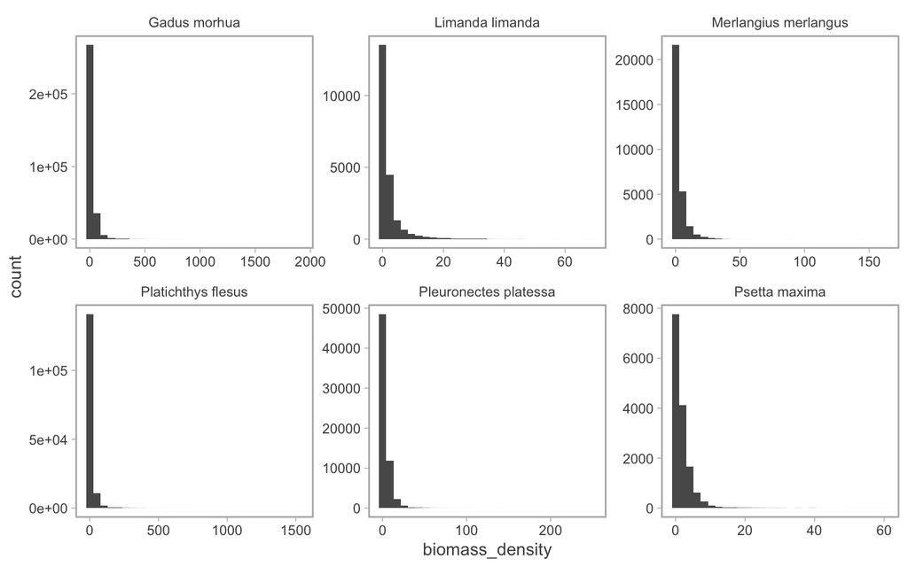

```r
dat |>
  ggplot(aes(biomass_density)) +
  geom_histogram() +
  facet_wrap(~species, scales = "free")
```

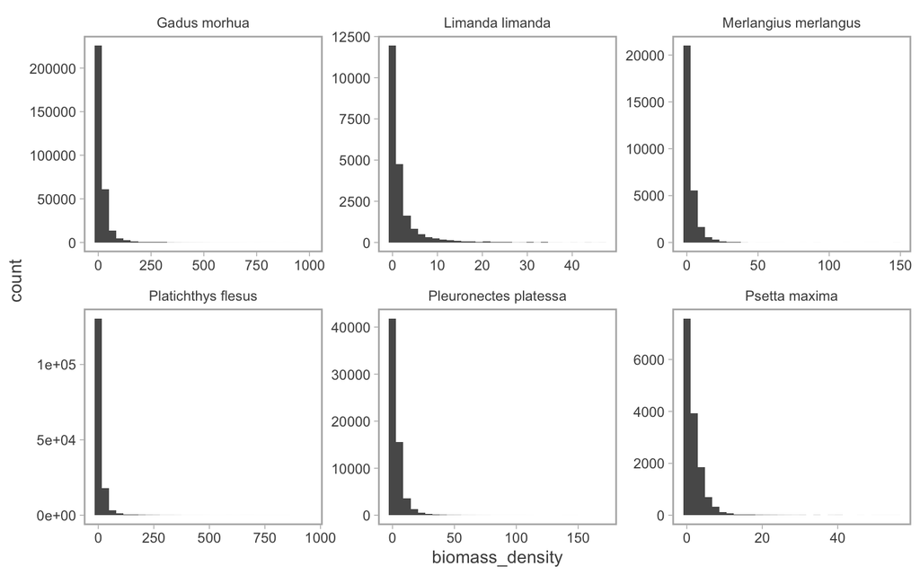

```r
# Remove some extreme values
dat <- dat |>
  mutate(extreme = quantile(biomass_density, 0.9999), .by = species) |>
  filter(biomass_density < extreme) |> dplyr::select(-extreme)

dat |>
  ggplot(aes(biomass_density)) +
  geom_histogram() +
  facet_wrap(~species, scales = "free")
```

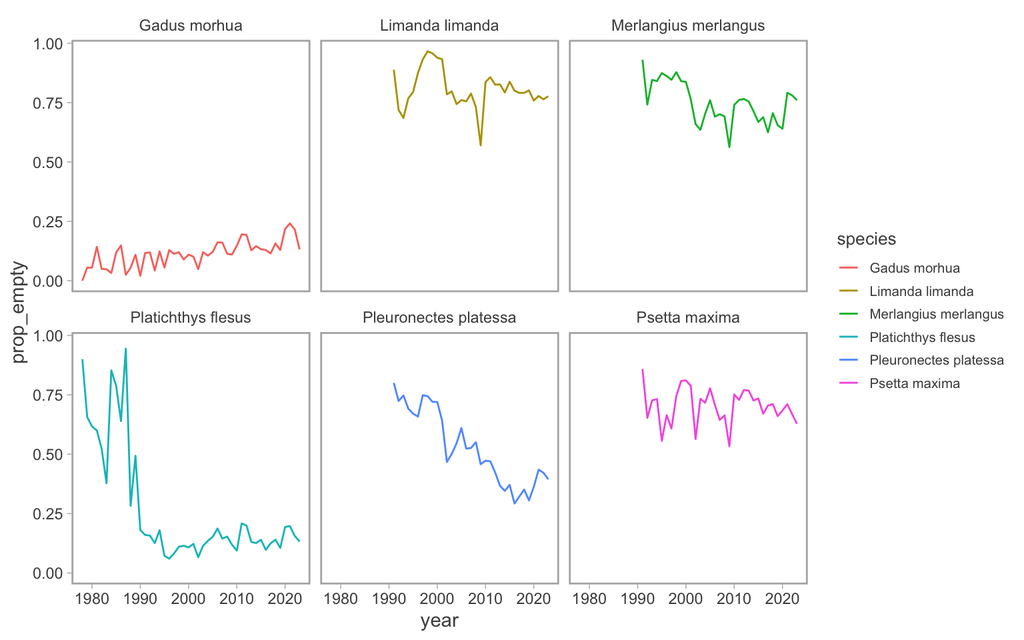

```r
# Average proportions 0's
# Interesting to note the very low presences in flounder in the mid 80's. I think it's correct, and it's a country effect. Basically, the Latvian 1980's data did not have lots of flounder! The catches are not extremely small though, mean is actually higher than Sweden but that's largely due to an outlier...
dat |>
  summarise(tot_catch = sum(biomass_density), .by = c(haul_id, species, year)) |>
  mutate(catch = ifelse(tot_catch == 0, "N", "Y")) |>
  summarise(prop_empty = mean(catch == "N"), .by = c(species, year)) |>
  ggplot(aes(year, prop_empty, color = species)) +
  facet_wrap(~species) +
  geom_line()
```

```r
# tibble(catch = c("N", "N", "N", "N", "Y", "Y"),
#        year = rep(c(1999, 2000), each = 3)) |>
#   summarise(mean = mean(catch == "N"), .by = year)

write_csv(dat, paste0(home, "/data/clean/cpue_length.csv"))
```